# ILO summary

DARS

6/26/2019

# Introduction

In this section I give a basic overview of our data. ##Import data

```r
ilo_data <- read_excel("~/Documents/Summer UCM/ILO/ILO_2018_2019.xlsx", na = c("", "NA"))
ilo_data <- ilo_data %>% mutate(Level = str_sub(Course, start = 4, end = 4), Concentration = str_sub(Course, start = 1, end = 3))
```

## Number of courses

I have data for:

```r
no_courses <- ilo_data %>% select(Course) %>% unique() %>% count() %>% pull(n)
print(no_courses)
```

```
## [1] 141
```

```r
rm(no_courses)
```

these do not include the projects.

## Distribution of ILO per course

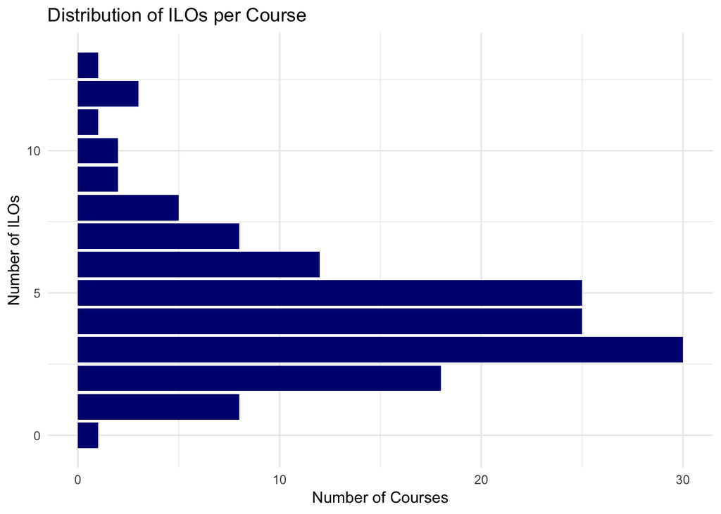

```r
ilo_data %>%
  mutate(not_empty = !is.na(ILO)) %>%
  group_by(Course) %>%
  summarise(Number_ilos = sum(not_empty)) %>%
  count(Number_ilos) %>%
  ggplot(aes(x = Number_ilos, y = n)) +
  geom_histogram(stat = "identity", fill = "navy") +
  labs(title= "Distribution of ILOs per Course", x = "Number of ILOs", y = "Number of Courses") +
  coord_flip() +
  theme_minimal()
```

###Total number of ILOS

```r
ilo_data %>%
  transmute(not_empty = !is.na(ILO)) %>% summarize(total_ilos = sum(not_empty))
```

```
## # A tibble: 1 x 1
##   total_ilos
##        <int>
## 1        625
```

## Course vs Student orientation

ILOs are formulated either as student learning goals or course objectives:

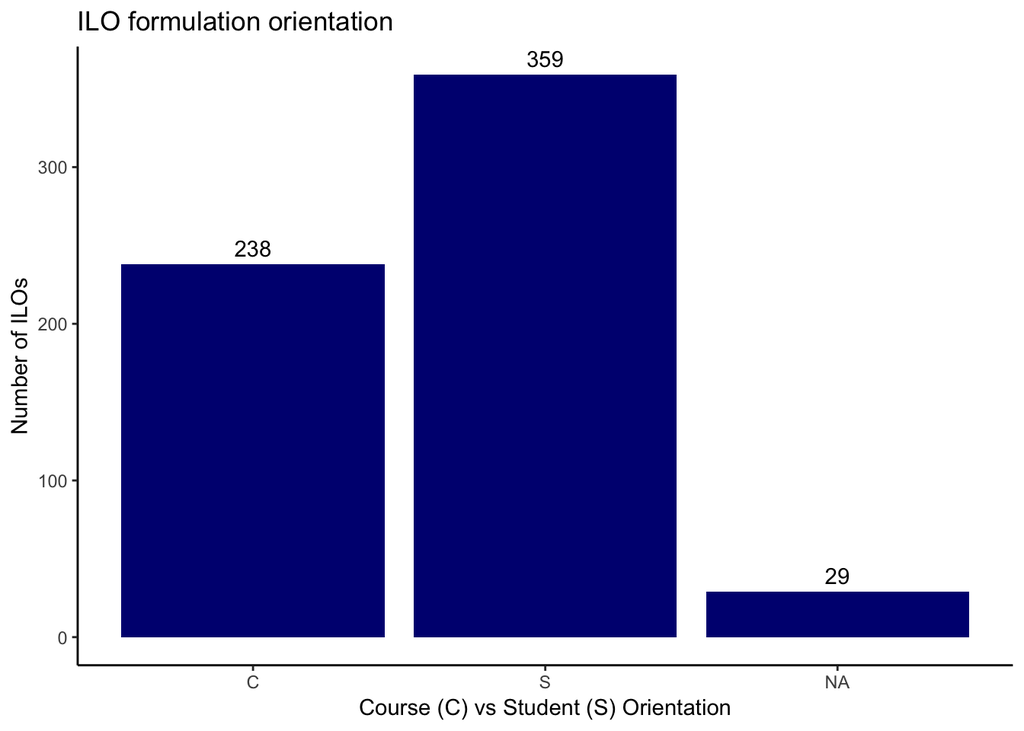

```r
ilo_data %>% select(`Course_Intention/Student_profile`) %>% group_by(`Course_Intention/Student_profile`) %>% count() %>%
  ggplot(aes(x = `Course_Intention/Student_profile`, y = n, label = n)) +
  geom_histogram(stat = "identity", fill = "navy")+
  geom_text(vjust = -0.5) +
  labs(title = "ILO formulation orientation", x = "Course (C) vs Student (S) Orientation", y = "Number of ILOs")+
  theme_classic()
```

in percentages:

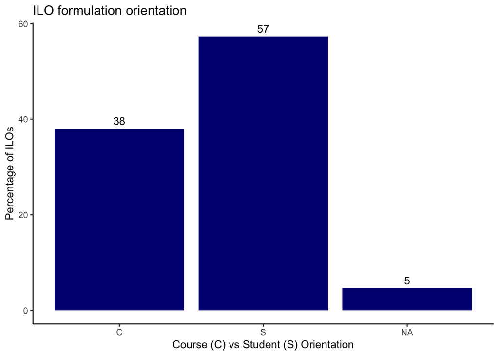

```r
ilo_data %>% select(`Course_Intention/Student_profile`) %>% group_by(`Course_Intention/Student_profile`) %>% count() %>%
  ungroup() %>%
  mutate(percentage = n*100/sum(n)) %>%
  ggplot(aes(x = `Course_Intention/Student_profile`, y = percentage, label = round(percentage))) +
  geom_histogram(stat = "identity", fill = "navy")+
  geom_text(vjust = -0.5) +
  labs(title = "ILO formulation orientation", x = "Course (C) vs Student (S) Orientation", y = "Percentage of ILOs")+
  theme_classic()
```

the ILOs I did not know how to classify are:

```r
ilo_data %>% filter(is.na(`Course_Intention/Student_profile`)) %>% select(Course, ILO)
```

```
## # A tibble: 29 x 2
##    Course  ILO
##    <chr>   <chr>
##  1 SCI2009 1. Human Cells and functions
##  2 SCI2009 2. Functional organization of the body
##  3 SCI2009 3. Membrane Physiology
##  4 SCI2009 4. Cardiac function and blood pressure control
##  5 SCI2009 5. Red blood cell function and gas transport and exchange
##  6 SCI2009 6. Pulmonary ventilation and regulation
##  7 SCI2009 7. Kidney function, intra-and extracellular compartments
##  8 SCI2009 8. Neuronal control
##  9 SCI2009 9. Hormonal control
## 10 SCI2009 10. Gastrointestinal Physiology
## # ... with 19 more rows
```

## Basic Text analysis

I count the appearance of words accross all courses, and add that number to the dataframe.

```r
ilo_unnested <-  ilo_data %>%
  select(Course, ILO, Level, Concentration) %>%
  unnest_tokens(word, ILO)

# basic_word_counts <- ilo_unnested %>%
#   count(word)

# ilo_word_counts <- ilo_unnested %>% left_join(basic_word_counts, by = "word")
#
# ilo_word_counts
```

```r
#basic_word_counts
```

### Classes of words

I will manually remove some of the common words such as prepositions and conjunctions:

```r
prepositions <- c(
      "with", "at", "from", "into", "during", "including", "until", "against", "among", "throughout",
      "despite", "towards", "upon", "concerning", "to", "in", "for", "of", "on", "by", "about", "like", "through",
      "over","before", "between", "after","since","without", "under", "within","along","following", "across",
      "behind","beyond", "plus", "except", "but", "up","out", "around", "down", "off", "above", "near"
)

conjunctions <- c("and", "or", "but","nor", "for","yet", "after", "although", "as", "because", "before","even", "once", "since", "though", "till", "unless", "until", "what", "when", "whenever", "wherever", "whether","while")

determiners <- c("this", "that", "these", "those")

articles <- c("the", "a", "an")

pronouns <- c("it", "one", "you", "we", "they",
              "his", "hers", "ours", "their")

my_stopwords <- c(word = c(prepositions, conjunctions, articles, determiners, pronouns))

#Clean workspace
rm(prepositions, conjunctions, articles, determiners, pronouns)
```

removing common words:

```r
basic_word_counts %>%
  filter(!str_detect(word,"[0-9]+")) %>% #remove numbers
  filter(! word %in% my_stopwords)
```

[output not shown]

### Universal part of speech

Alternatively, we should check out this package, created by the Institute of Formal and Applied Linguistics of Charles University, Czech Republic at the Faculty of Mathematics and Physics. http://ufal.mff.cuni.cz/udpipe

Lables are as follows: ADJ: adjective ADP: adposition ADV: adverb AUX: auxiliary CCONJ: coordinating conjunction DET: determiner INTJ: interjection NOUN: noun NUM: numeral PART: particle PRON: pronoun PROPN: proper noun PUNCT: punctuation SCONJ: subordinating conjunction SYM: symbol VERB: verb X: other

```r
# library(udpipe)

english_lang_model <- udpipe_download_model(language = "english")
```

```
## Visit https://github.com/jwijffels/udpipe.models.ud.2.4 for model license details
```

```r
udmodel_english <- udpipe_load_model(file = english_lang_model$file_model)
s <- udpipe_annotate(udmodel_english, ilo_unnested$word)
x <- data.frame(s) %>% select(token, upos, xpos) %>% distinct()

#rm(english_lang_model, udmodel_english, s)
```

Annotating the data based on the language model:

```r
annotated_ilo <- ilo_unnested %>% left_join(x, by = c("word" = "token"))
```

Filtering for verbs:

```r
verbs_in_ilos <- annotated_ilo %>%
  filter(upos == "VERB")
```

Universal Verb counts

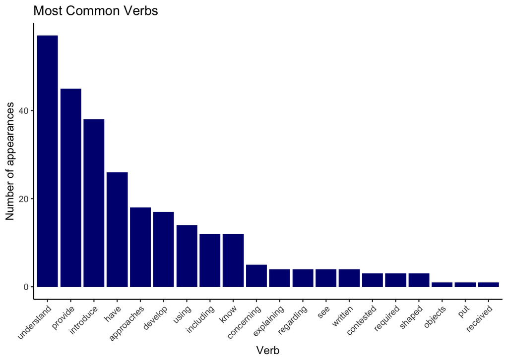

```r
verbs_unrepeated <- verbs_in_ilos %>%
  group_by(word) %>%
  mutate(n = n()) %>%
  select(word, n) %>%
  distinct()

verbs_unrepeated %>%
  top_n(n = 20, wt = n) %>%
  ungroup() %>%
  .[1:20,] %>%
  ggplot(aes(x = reorder(word,-n), y = n))+
  geom_histogram(stat = "identity", fill = "navy")+
  labs(title = "Most Common Verbs", x = "Verb", y = "Number of appearances")+
  theme_classic() +
  theme(axis.text.x = element_text(angle = 45, hjust = 1))
```

#### Breakdown by Level

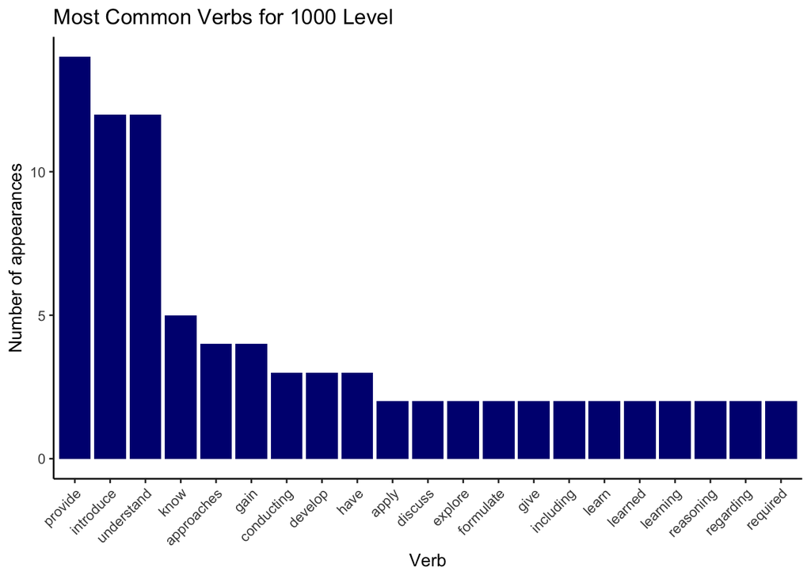

```r
verbs_unrepeated <- verbs_in_ilos %>%
  group_by(Level, word) %>%
  mutate(n = n()) %>%
  select(Level, word, n) %>%
  distinct()

d_level_plots <- verbs_unrepeated %>%
  group_by(Level) %>%
  top_n(n = 20, wt = n) %>%
  ungroup()

#Level 1000
d_level_plots %>%
  filter(Level == 1) %>%
  ggplot(aes(x = reorder(word,-n), y = n)) +
  geom_histogram(stat = "identity", fill = "navy") +
  labs(title = "Most Common Verbs for 1000 Level", x = "Verb", y = "Number of appearances")+
  theme_classic() +
  theme(axis.text.x = element_text(angle = 45, hjust = 1))
```

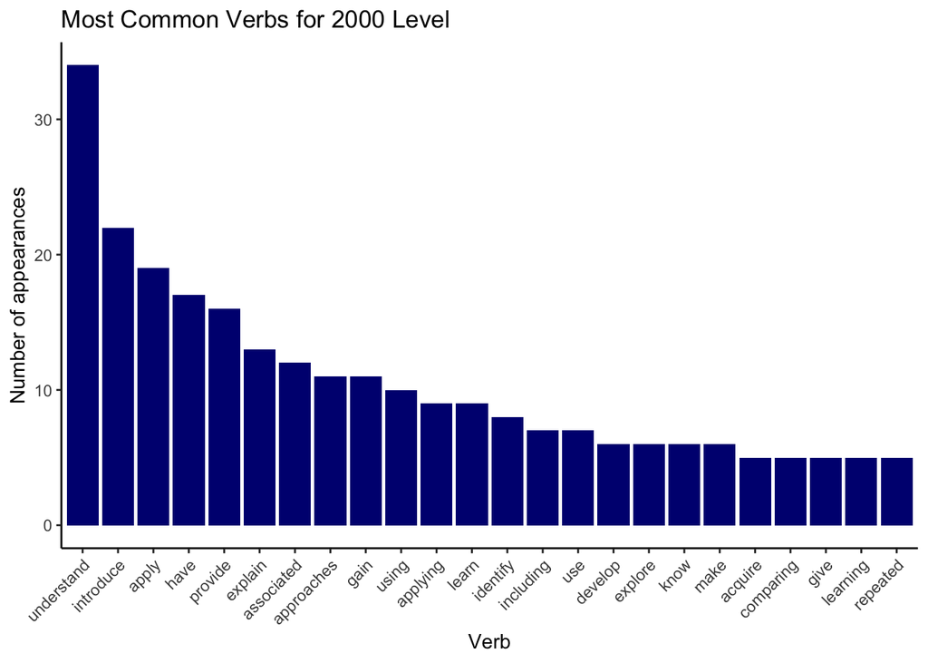

```r
#Level2000
d_level_plots %>%
  filter(Level == 2) %>%
  ggplot(aes(x = reorder(word,-n), y = n)) +
  geom_histogram(stat = "identity", fill = "navy") +
  labs(title = "Most Common Verbs for 2000 Level", x = "Verb", y = "Number of appearances")+
  theme_classic() +
  theme(axis.text.x = element_text(angle = 45, hjust = 1))
```

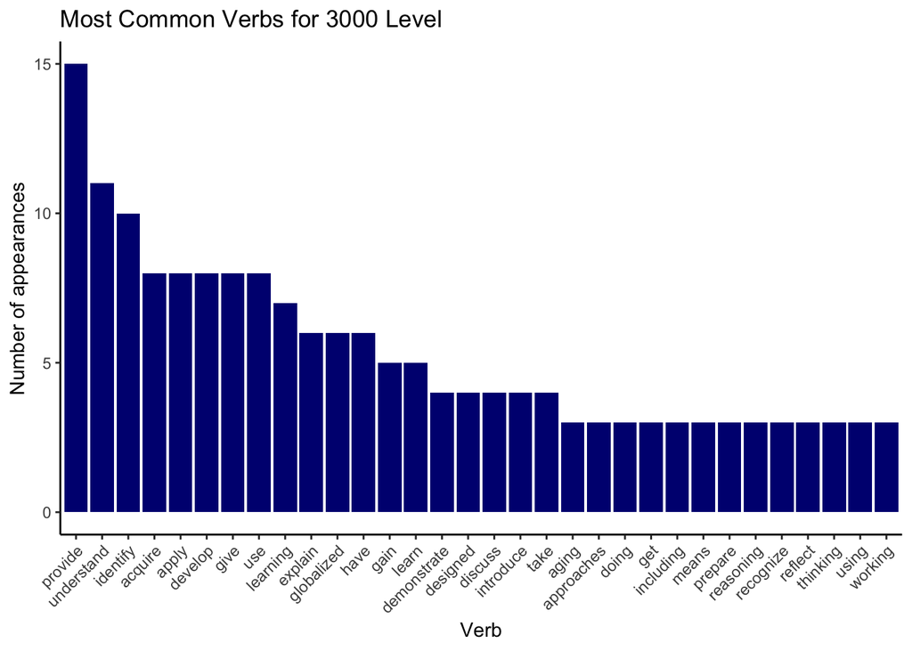

```r
#Level3000
d_level_plots %>%
  filter(Level == 3) %>%
  ggplot(aes(x = reorder(word,-n), y = n)) +
  geom_histogram(stat = "identity", fill = "navy") +
  labs(title = "Most Common Verbs for 3000 Level", x = "Verb", y = "Number of appearances")+
  theme_classic() +
  theme(axis.text.x = element_text(angle = 45, hjust = 1))
```

# Manual analysis display

For each of the ILOs the verb describing what the student is intended to learn was extracted manually. This created a distiction between the course verb and the student verb. For instance, for the ILO “to provide students with […] perspectives to examine…” (COR1004, p.1) the extracted verb is “[to] examine”.

Let’s have a look at all the verbs I extracted.

First, I clean the data to have all verbs in one column. I replace `NA` with a character (`"NaN"`) to be able to remove `NA`s created by `gather`, after those have been filtered out, I return `"NaN"` to `NA`.

```r
ilo_data_clean <- ilo_data %>%
  mutate(Verb_used_1 = case_when(is.na(Verb_used_1)~"NaN",
                                            T~Verb_used_1))      %>%
  gather(key = tmp_place, value = Verb, Verb_used_1:Verd_used_3) %>%
  select(-tmp_place) %>%
  filter(!is.na(Verb)) %>%
  mutate(Verb = map_chr(Verb, function(x) str_replace(x,"NaN",NA_character_)))
```

```r
dirty_verbs <- ilo_data_clean %>% pull(Verb) %>% unique()
dirty_verbs
```

```
##   [1] "to know"
##   [2] "to have knowledge"
##   [3] "to understand"
##   [4] "to develop attitude"
##   [5] "to develop understanding"
##   [6] "basic understanding"
##   [7] "get overview"
##   [8] "work with models"
##   [9] "model"
##  [10] "acquaint"
##  [11] "familiarize"
##  [12] "introduce"
##  [13] "examine"
##  [14] "develop own analysis"
##  [15] "[get] notion"
```

[output cut: 209 more lines]

as you can see some verbs are really similar, for example, we have: “to understand”, “understand” and “basic understanding”. Let’s group all of these together.

We will need an or function to help with regular expressions:

```r
collapse_or <- function(string_vector){
  paste(string_vector, collapse ="$|^")
}
```

First find similarities

```r
#UNDERSTAND
understand_eq <- ilo_data_clean %>% filter(str_detect(Verb, "understa")) %>% pull(Verb) %>% unique()
print(paste('"understand":', paste(understand_eq, collapse = ", "), sep = " "))
```

```
## [1] "\"understand\": to understand, to develop understanding, basic understanding, understand, gain understanding, develop own understaning, understand (critically)"
```

```r
#KNOW
know_eq <- ilo_data_clean %>% filter(str_detect(Verb, "know")) %>% pull(Verb) %>% unique()
print(paste('"know":', paste(know_eq, collapse = ", "), sep = " ")) # "gain "basic practial knowledge" and "use knowledge" might not be correct here rather in "apply".
```

```
## [1] "\"know\": to know, to have knowledge, basic knowledge, know, gain basic practical knowledge, obtain basic knowledge, use knowledge"
```

```r
#[GAIN] FAMILIARITY
familiarise_eq <- ilo_data_clean %>% filter(str_detect(Verb, "familia")) %>% pull(Verb) %>% unique()
print(paste('"[gain] familiarity":', paste(familiarise_eq, collapse = ", "), sep = " "))
```

```
## [1] "\"[gain] familiarity\": familiarize, [gain] familiarity"
```

```r
#ANALYSE
analyse_eq <- ilo_data_clean %>% filter(str_detect(Verb, "analy")) %>% pull(Verb) %>% unique()
print(paste('"analyse":', paste(analyse_eq, collapse = ", "), sep = " "))
```

```
## [1] "\"analyse\": develop own analysis, analyse, critically analyse, reason analyticaly, define/analyse/answer, to further (research, analyical and writing skills)"
```

```r
#[BE] INTRODUCED
introduce_eq <- ilo_data_clean %>% filter(str_detect(Verb, "introd")) %>% pull(Verb) %>% unique()
print(paste('"[be] introduced":', paste(introduce_eq, collapse = ", "), sep = " "))
```

```
## [1] "\"[be] introduced\": introduce, [get] introduction, basic introduction"
```

```r
#[GET] OVERVIEW
overview_eq <- ilo_data_clean %>% filter(str_detect(Verb, "overv")) %>% pull(Verb) %>% unique()
print(paste('"[get] overview":', paste(overview_eq, collapse = ", "), sep = " "))
```

```
## [1] "\"[get] overview\": get overview, [get] overview"
```

```r
#[GET] ACQUAINTED
acquainted_eq <- ilo_data_clean %>% filter(str_detect(Verb, "acquain")) %>% pull(Verb) %>% unique()
print(paste('"[get] acquainted":', paste(acquainted_eq, collapse = ", "), sep = " "))
```

```
## [1] "\"[get] acquainted\": acquaint, get acquainted"
```

NOTES: *“gain basic practial knowledge” and “use knowledge” might not be correct under “know” rather in “apply”.* “think analytically” and “reason analyticaly” don’t have a clear interpretation to me.

We notice that some of the words recognized by are not quite equivalent. Therefore, I create equivalent classes for filtering:

```r
#UNDERSTAND
understand_equivalence <- setdiff(understand_eq, c(""))
print(paste('The verbs that were taken to be the same as "understand" are:', paste(understand_equivalence, collapse = ", "), sep = " "))
```

```
## [1] "The verbs that were taken to be the same as \"understand\" are: to understand, to develop understanding, basic understanding, understand, gain understanding, develop own understaning, understand (critically)"
```

```r
#KNOW
know_equivalence <- setdiff(know_eq, c("use knowledge","gain basic practical knowledge"))
print(paste('The verbs that were taken to be the same as "know" are:', paste(know_equivalence, collapse = ", "), sep = " ")) # "gain "basic practial knowledge" and "use knowledge" might not be correct here rather in "apply".
```

```
## [1] "The verbs that were taken to be the same as \"know\" are: to know, to have knowledge, basic knowledge, know, obtain basic knowledge"
```

```r
#[GAIN] FAMILIARITY
familiarise_equivalence <- setdiff(familiarise_eq, c(""))
print(paste('The verbs that were taken to be the same as "[gain] familiarity" are:', paste(familiarise_equivalence, collapse = ", "), sep = " "))
```

```
## [1] "The verbs that were taken to be the same as \"[gain] familiarity\" are: familiarize, [gain] familiarity"
```

```r
#ANALYSE
analyse_equivalence <- setdiff(analyse_eq, c("to further (research, analyical and writing skills)", "define/analyse/answer", "reason analyticaly", "think analytically"))
print(paste('The verbs that were taken to be the same as "analyse" are:', paste(analyse_equivalence, collapse = ", "), sep = " "))
```

```
## [1] "The verbs that were taken to be the same as \"analyse\" are: develop own analysis, analyse, critically analyse"
```

```r
#[BE] INTRODUCED
introduce_equivalence <- setdiff(introduce_eq, c(""))
print(paste('The verbs that were taken to be the same as "[be] introduced" are:', paste(introduce_equivalence, collapse = ", "), sep = " "))
```

```
## [1] "The verbs that were taken to be the same as \"[be] introduced\" are: introduce, [get] introduction, basic introduction"
```

```r
#[GET] OVERVIEW
overview_equivalence <- setdiff(overview_eq, c(""))
print(paste('The verbs that were taken to be the same as "[get] overview" are:', paste(overview_equivalence, collapse = ", "), sep = " "))
```

```
## [1] "The verbs that were taken to be the same as \"[get] overview\" are: get overview, [get] overview"
```

```r
#[GET] ACQUAINTED
acquainted_equivalence <- setdiff(acquainted_eq, c(""))
print(paste('The verbs that were taken to be the same as "[get] acquainted" are:', paste(acquainted_equivalence, collapse = ", "), sep = " "))
```

```
## [1] "The verbs that were taken to be the same as \"[get] acquainted\" are: acquaint, get acquainted"
```

Next, I create standardizing functions that use those equivalent classes to replace all verbs in the same class for a single verb.

```r
#Clean functions
remove_to <- function(string){
  str_replace(string, "to ", "")
}

#Standardize functions
standardize_knowing <- function(string){
  str_replace(string, collapse_or(know_equivalence), "know")
}

standardize_understand <- function(string){
  str_replace(string, collapse_or(understand_equivalence), "understand")
}

standardize_familiarity <- function(string){
  str_replace(string, collapse_or(familiarise_equivalence), "[gain] familiarity")
}

standardize_analyse <- function(string){
  str_replace(string, collapse_or(analyse_equivalence), "analyse")
}

standardize_introduce <- function(string){
  str_replace(string, collapse_or(introduce_equivalence), "[be] introduced")
}

standardize_overview <- function(string){
  str_replace(string, collapse_or(overview_equivalence), "[get] overview")
}

standardize_acquainted <- function(string){
  str_replace(string, collapse_or(acquainted_equivalence), "[get] acquainted")
}
```

```r
ilo_data_clean <- ilo_data_clean %>%
  mutate(
    Verb = map_chr(Verb, standardize_knowing),
    Verb = map_chr(Verb, standardize_understand),
    Verb = map_chr(Verb, standardize_familiarity),
    Verb = map_chr(Verb, standardize_analyse),
    Verb = map_chr(Verb, standardize_introduce),
    Verb = map_chr(Verb, standardize_overview),
    Verb = map_chr(Verb, standardize_acquainted),
    Verb = map_chr(Verb, function(string) str_replace(string, "to ", "")) #,
    #Verb = map_chr(Verb, function(string) str_replace(string, "^na$", NA_character_)) #this should not be necessary anymore.
  )
```

```r
ilo_data_clean %>% View()
```

Time for some summary graphs and summary statistics: ###Summary Statistics ####Total verbs in ILOs:

```r
total_objectives <- ilo_data_clean %>% group_by(ILO) %>% mutate(Verbs_per_ILO = n()) %>%

# for verification join with:
# %>% arrange(Course, ILO) %>% select(Course, Verbs_per_ILO, Verb, ILO, everything())
  ungroup() %>%
  select(Course, Level, Concentration, ILO, Verbs_per_ILO) %>%
  distinct() %>%
  group_by(Course) %>%
  mutate(ilo_per_course = n(),
         verbs_per_course = sum(Verbs_per_ILO)) %>%
  select(Course, verbs_per_course) %>%
  distinct() %>%
  ungroup() %>%
  summarize(total = sum(verbs_per_course)) %>%
  pull(total)

total_objectives
```

```
## [1] 856
```

we have 856 verbs (objectives). ###Graphs ####Universal Verbs Universal use of verbs:

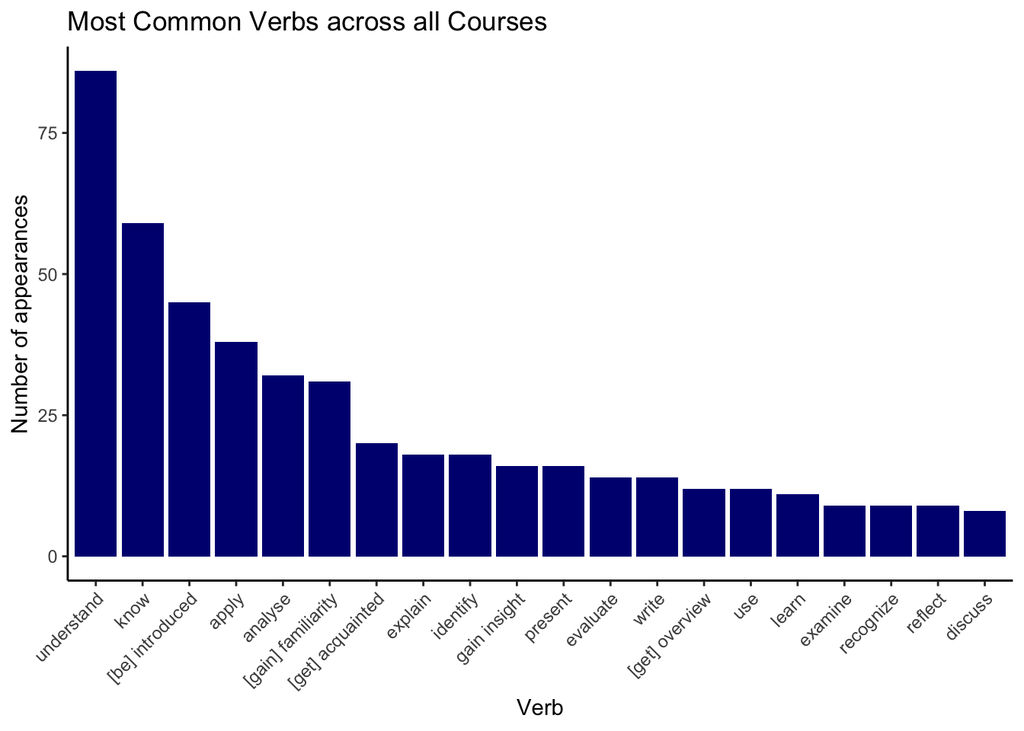

```r
verbs_unrepeated <- ilo_data_clean %>%
  group_by(Verb)  %>%
  mutate(n = n()) %>%
  select(Verb, n) %>%
  distinct()      %>%
  filter(!is.na(Verb)) #REMOVE NA

verbs_unrepeated        %>%
  top_n(n = 20, wt = n) %>%
  arrange(desc(n))      %>%
  ungroup()             %>%
  .[1:20,]              %>%
  ggplot(aes(x = reorder(Verb,-n), y = n)) +
  geom_histogram(stat = "identity", fill = "navy") +
  labs(title = "Most Common Verbs across all Courses", x = "Verb", y = "Number of appearances") +
  theme_classic() +
  theme(axis.text.x = element_text(angle = 45, hjust = 1))
```

#### Breakdown by Level

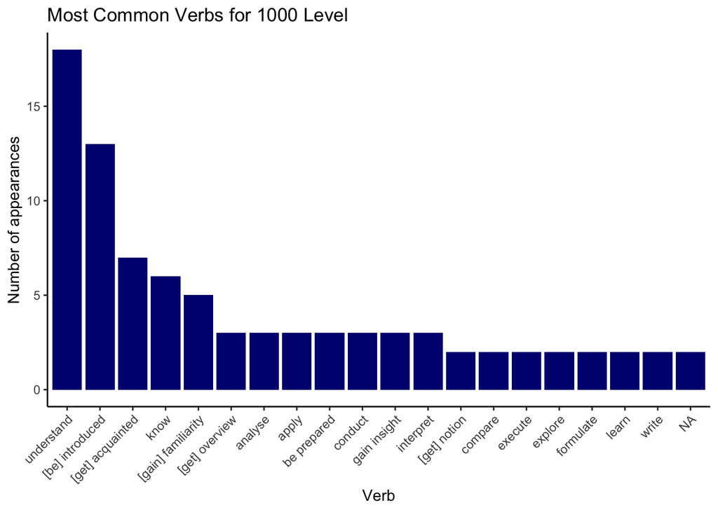

```r
verbs_unrepeated <- ilo_data_clean %>%
  group_by(Level, Verb)            %>%
  mutate(n = n())                  %>%
  select(Level, Verb, n)           %>%
  distinct()

d_level_plots <- verbs_unrepeated %>%
  group_by(Level)                 %>%
  top_n(n = 20, wt = n)           %>%
  ungroup()

#Level 1000
d_level_plots %>%
  filter(Level == 1) %>%
  ggplot(aes(x = reorder(Verb,-n), y = n)) +
  geom_histogram(stat = "identity", fill = "navy") +
  labs(title = "Most Common Verbs for 1000 Level", x = "Verb", y = "Number of appearances")+
  theme_classic() +
  theme(axis.text.x = element_text(angle = 45, hjust = 1))
```

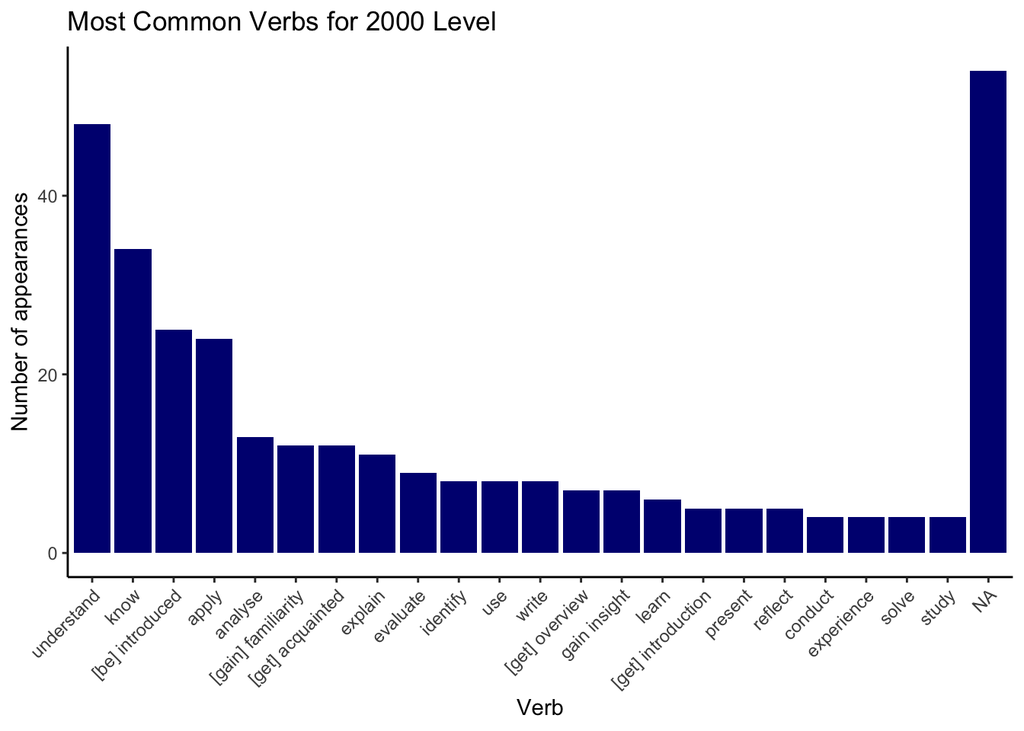

```r
#Level2000
d_level_plots %>%
  filter(Level == 2) %>%
  ggplot(aes(x = reorder(Verb,-n), y = n)) +
  geom_histogram(stat = "identity", fill = "navy") +
  labs(title = "Most Common Verbs for 2000 Level", x = "Verb", y = "Number of appearances")+
  theme_classic() +
  theme(axis.text.x = element_text(angle = 45, hjust = 1))
```

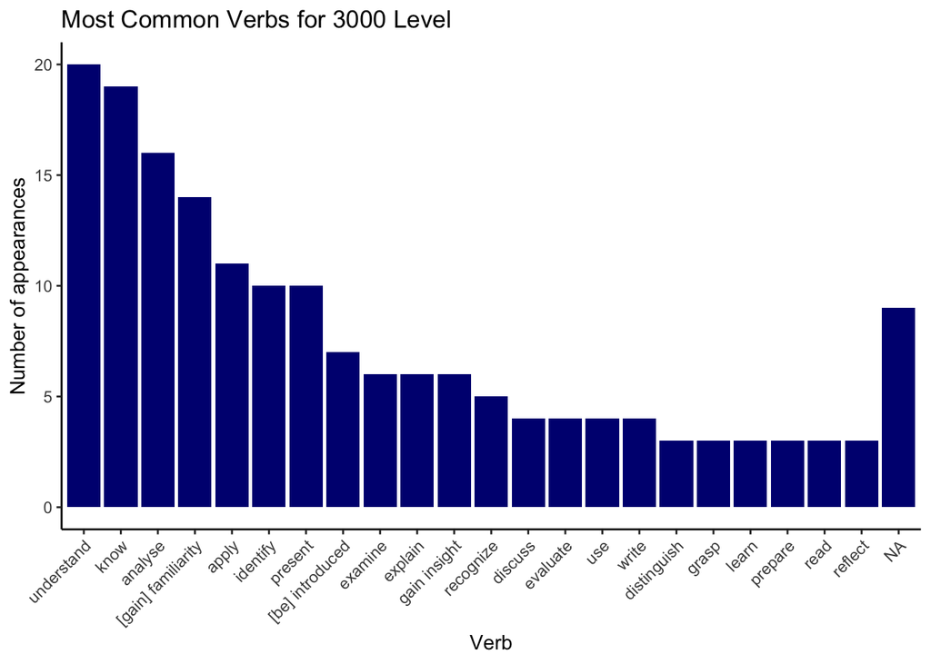

```r
#Level3000
d_level_plots %>%
  filter(Level == 3) %>%
  ggplot(aes(x = reorder(Verb,-n), y = n)) +
  geom_histogram(stat = "identity", fill = "navy") +
  labs(title = "Most Common Verbs for 3000 Level", x = "Verb", y = "Number of appearances")+
  theme_classic() +
  theme(axis.text.x = element_text(angle = 45, hjust = 1))
```